# Sleep analysis

This was a personal project of mine to revise for a statistics exam. I used R to analyze the effect of my daily activity score (percentage-based) on the following night’s sleep score (0-100) as provided by a Polar Ignite 3 fitness watch.

## The data:

```r
activity_scores = c(171, 56, 121, 16, 48, 36, 158, 22, 68, 21, 78, 35, 52, 132, 41, 27, 21, 79, 54, 32, 157, 41, 151, 61, 10, 49, 32, 204, 101, 75, 16, 52, 33, 187, 95, 120, 63, 27, 124, 74, 138, 72, 31, 80, 84, 38, 59, 69, 146, 71)

sleep_scores = c(83, 73, 63, 69, 70, 76, 85, 75, 59, 58, 74, 77, 63, 77, 71, 54, 64, 54,  73, 69, 65, 74, 70, 69, 62, 75, 75, 74, 61, 56, 72, 72, 61, 71, 71, 66, 64, 81, 79, 76, 77, 77, 55, 52, 72, 66, 71, 71, 62, 86)

activity_scores_scaled = activity_scores / length(activity_scores)

sleep_scores_scaled = sleep_scores / length(sleep_scores)
```

Fitting a linear model to the data:

```r
model = lm(sleep_scores ~ activity_scores)
model_scaled = lm(sleep_scores_scaled ~ activity_scores_scaled)
```

Plotting the data:

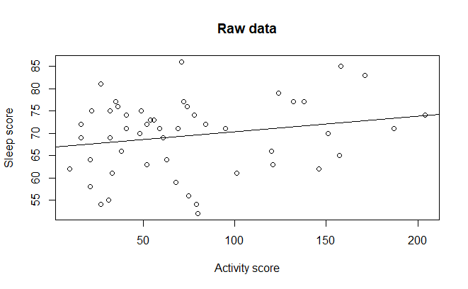

```r
plot(sleep_scores ~ activity_scores, main = "Raw data", xlab = "Activity score", ylab = "Sleep score")
abline(model)
```

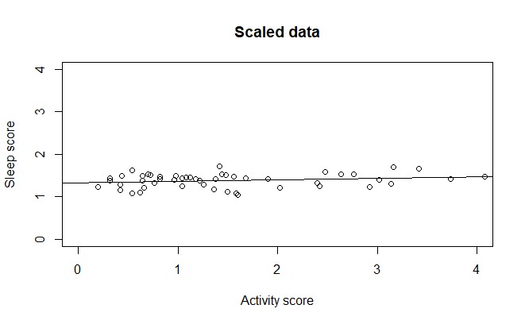

```r
plot(sleep_scores_scaled ~ activity_scores_scaled, main = "Scaled data", xlab = "Activity score", ylab = "Sleep score", xlim = c(0,4), ylim = c(0,4))
abline(model_scaled)
```

## Analysis:

```r
summary(model)
```

```
Call:
lm(formula = sleep_scores ~ activity_scores)

Residuals:
    Min      1Q  Median      3Q     Max
-17.591  -5.490   1.593   5.729  16.725

Coefficients:
                Estimate Std. Error t value Pr(>|t|)
(Intercept)     66.78425    2.08517  32.028   <2e-16 ***
activity_scores  0.03508    0.02336   1.502     0.14
---
Signif. codes:  0 ‘***’ 0.001 ‘**’ 0.01 ‘*’ 0.05 ‘.’ 0.1 ‘ ’ 1

Residual standard error: 8.106 on 48 degrees of freedom
Multiple R-squared:  0.04488,   Adjusted R-squared:  0.02498
F-statistic: 2.255 on 1 and 48 DF,  p-value: 0.1397
```

The R-squared value is 0.04488, which means that the model explains 4.5 % of the variance in the data. The p-value is 0.1397, so the model is not statistically significant.

```r
confint(model)
```

```
                      2.5 %      97.5 %
(Intercept)     62.59173259 70.97676983
activity_scores -0.01188794  0.08205287
```

The 95 % confidence interval for the slope is [-0.012, 0.082] and includes 0, so we can’t be certain that increasing the activity score has a positive effect on the sleep score, even though graphically it does seem to be the case.

## Conclusion:

There is not enough evidence to conclude that increasing my daily activity score has a positive effect on the following night’s sleep score. More data is required for a more accurate analysis. If additional data does not support a positive correlation, I can think of three possible conclusions: 1) the claim that activity improves sleep quality is bullsh*t, 2) Polar’s fitness watch is not very accurate, or 3) I am stressing my body too much after having just started working out and the results would be different had I been as active for a longer period of time.